# Experiment 4

2025-07-07

# Descriptive statistics

Count of of the answer choices in each condition

| CategoryType | Both | Is | Is not |
| --- | --- | --- | --- |
| Artifact | 93 | 53 | 136 |
| Clock | 7 | 1 | 39 |
| Comedian | 11 | 27 | 9 |
| Definite | 6 | 4 | 84 |
| Honeybees | 12 | 13 | 22 |
| Natural | 81 | 29 | 172 |
| Vague | 72 | 20 | 2 |
| Value | 118 | 71 | 93 |

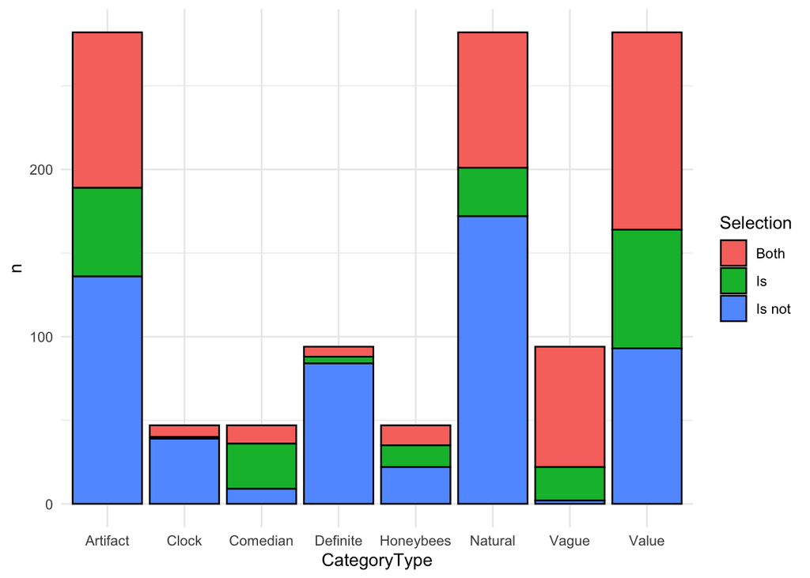

The distribution of selections for each category type

### The results of the model

Model structure: `brm(Selection ~ CategoryType + (CategoryType | Participant) + (1 | Item)`

`Selection` had three levels: “Both”,“Is not”, and “Is”. The model predicted the log-odds of each choice as a function of `CategoryType`.

`Participant`: There were 47 participants, each with 25 data points total (6 per `CategoryType`). the model included a random slope of category type per participant. This both takes into account the nested structure of the data and allows for the estimation of individual probabilities per `CategoryType`.

The table below reports the fixed effects and intercepts, as well as convergence metrics. This should be reported, but we won’t use this to make inferences directly.

| Parameter | Median | CI_low | CI_high | pd | ROPE_Percentage | Rhat | ESS |
| --- | --- | --- | --- | --- | --- | --- | --- |
| Intercept ‘is’ | -0.49 | -1.06 | 0.10 | 0.95 | 0.13 | 1 | 1809 |
| Intercept ‘is not’ | 2.46 | 1.52 | 3.45 | 1.00 | 0.00 | 1 | 1011 |
| Is_CategoryTypeArtifact | -1.14 | -1.98 | -0.38 | 1.00 | 0.00 | 1 | 2598 |
| Is_CategoryTypeNatural | -1.53 | -2.33 | -0.74 | 1.00 | 0.00 | 1 | 2892 |
| Isnot_CategoryTypeArtifact | 0.40 | -0.57 | 1.33 | 0.79 | 0.22 | 1 | 2306 |
| Isnot_CategoryTypeNatural | -6.43 | -7.44 | -5.39 | 1.00 | 0.00 | 1 | 3940 |

## The conditional effects based on the model

This plot and table were generated from the model using the `conditional_effects` function in R. The function just does the addition needed and conversion to probability as a convenience.

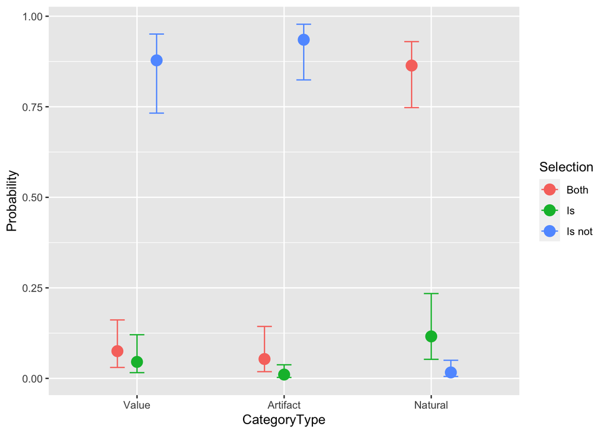

| CategoryType | Both | Is | Is not |
| --- | --- | --- | --- |
| Value | 0.08 [0.03 - 0.16] | 0.05 [0.02 - 0.12] | 0.88 [0.73 - 0.95] |
| Artifact | 0.05 [0.02 - 0.14] | 0.01 [0 - 0.04] | 0.94 [0.82 - 0.98] |
| Natural | 0.86 [0.75 - 0.93] | 0.12 [0.05 - 0.23] | 0.02 [0.01 - 0.05] |

# The pairwise comparisons

## Both-both across categories

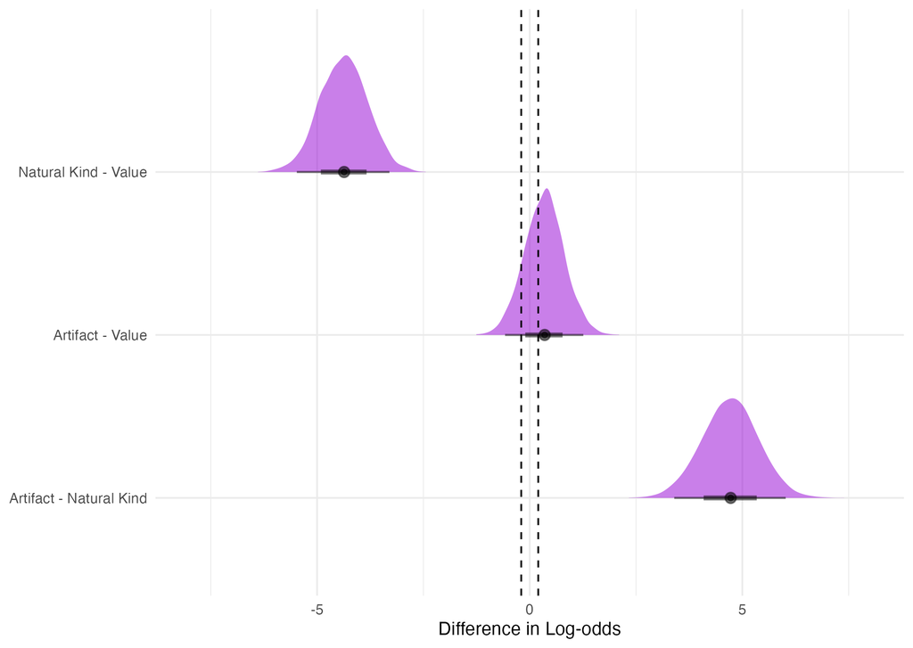

| Comparison | Effect | Compelling_difference |
| --- | --- | --- |
| Both_Natural_Both_Value | -4.37 [-5.48 - -3.3] | Yes |
| Both_Artifact_Both_Value | 0.34 [-0.58 - 1.26] | No |
| Both_Artifact_Both_Natural | 4.72 [3.46 - 6.04] | Yes |

# Is-is across categories

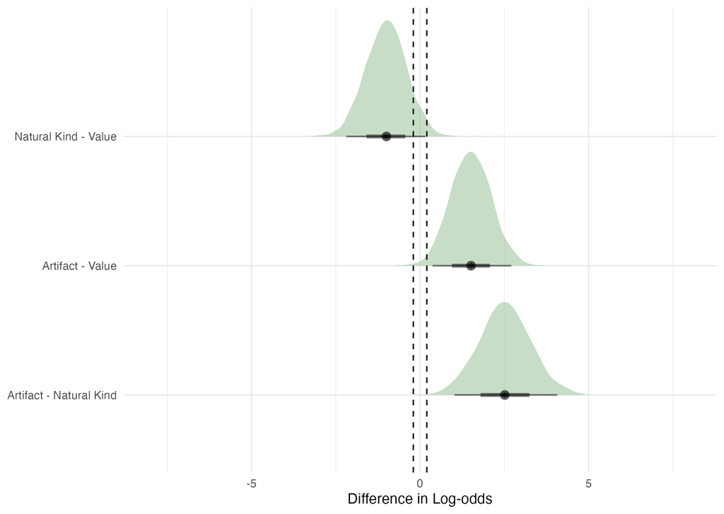

| Comparison | Effect | Compelling_difference |
| --- | --- | --- |
| Is_Natural_Is_Value | -1.01 [-2.13 - 0.19] | No |
| Is_Artifact_Is_Value | 1.51 [0.36 - 2.69] | Yes |
| Is_Artifact_Is_Natural | 2.52 [0.92 - 3.98] | Yes |

# Is not - is not across categories

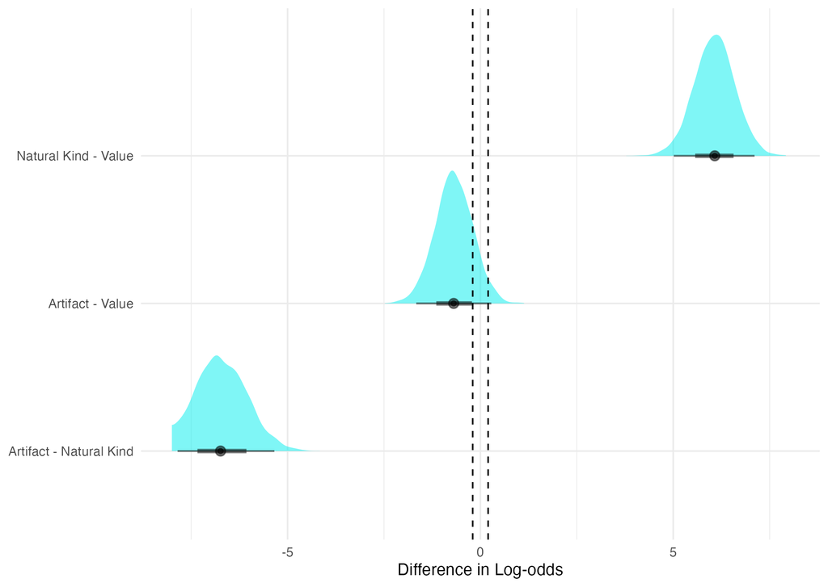

| Comparison | Effect | Compelling_difference |
| --- | --- | --- |
| Is not_Natural_Is not_Value | 6.07 [4.96 - 7.05] | Yes |
| Is not_Artifact_Is not_Value | -0.69 [-1.61 - 0.34] | No |
| Is not_Artifact_Is not_Natural | -6.76 [-8.1 - -5.32] | Yes |

# Both, is, is not within natural kinds

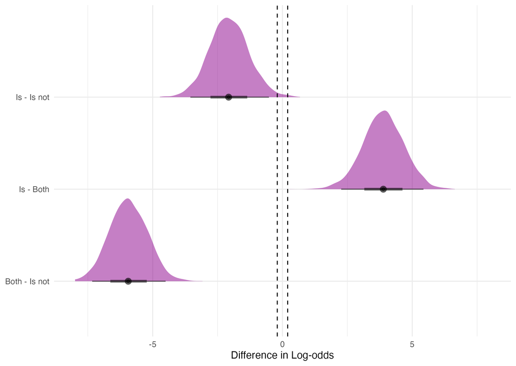

| Comparison | Effect | Compelling_difference |
| --- | --- | --- |
| Is_Natural_Is not_Natural | -2.06 [-3.62 - -0.6] | Yes |
| Is_Natural_Both_Natural | 3.88 [2.4 - 5.49] | Yes |
| Both_Natural_Is not_Natural | -5.94 [-7.41 - -4.56] | Yes |

# Both, is, is not within artifacts

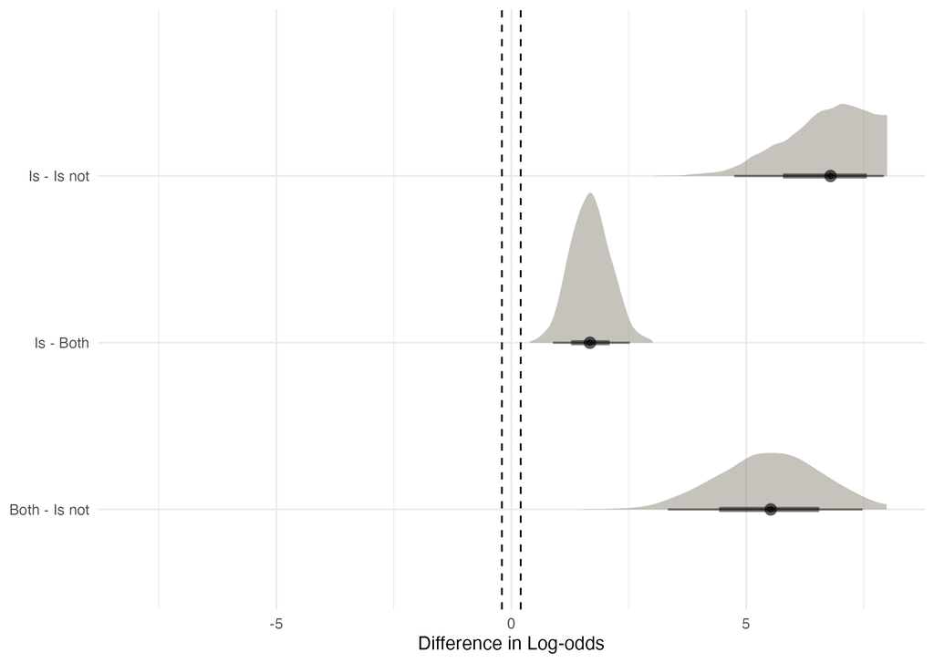

| Comparison | Effect | Compelling_difference |
| --- | --- | --- |
| Is_Artifact_Is not_Artifact | 7.22 [4.77 - 9.48] | Yes |
| Is_Artifact_Both_Artifact | 1.68 [0.9 - 2.53] | Yes |
| Both_Artifact_Is not_Artifact | 5.53 [3.33 - 7.74] | Yes |

# Both, is, is not within value

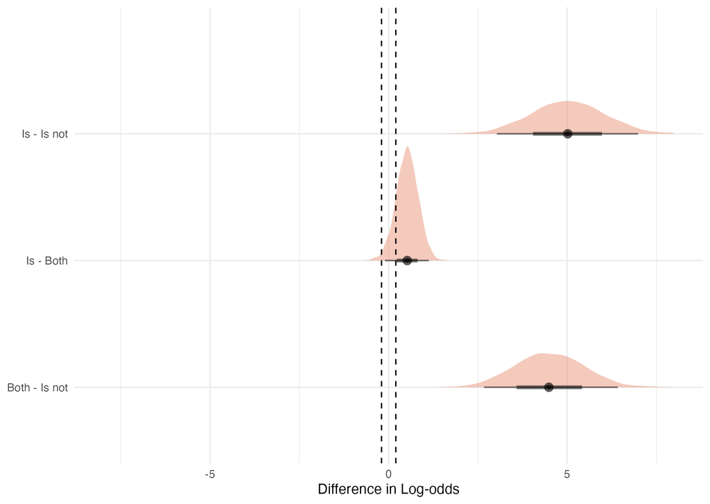

| Comparison | Effect | Compelling_difference |
| --- | --- | --- |
| Is_Value_Is not_Value | 5.02 [3 - 7.01] | Yes |
| Is_Value_Both_Value | 0.52 [-0.14 - 1.08] | No |
| Both_Value_Is not_Value | 4.5 [2.64 - 6.34] | Yes |

# Sensitivity analysis

| Parameter | Median | CI_low | CI_high | pd | ROPE_Percentage | Rhat | ESS |
| --- | --- | --- | --- | --- | --- | --- | --- |
| Intercept ‘is’ | -0.71 | -1.54 | 0.03 | 0.97 | 0.06 | 1 | 1777 |
| Intercept ‘is not’ | -0.53 | -1.49 | 0.39 | 0.87 | 0.17 | 1 | 1399 |
| Is_CategoryTypeArtifact | -0.46 | -1.81 | 0.71 | 0.78 | 0.19 | 1 | 1516 |
| Is_CategoryTypeNatural | -2.04 | -4.27 | -0.45 | 0.99 | 0.00 | 1 | 1321 |
| Isnot_CategoryTypeArtifact | 0.99 | -0.47 | 2.45 | 0.91 | 0.08 | 1 | 1282 |
| Isnot_CategoryTypeNatural | 1.63 | 0.29 | 3.09 | 0.99 | 0.00 | 1 | 1217 |

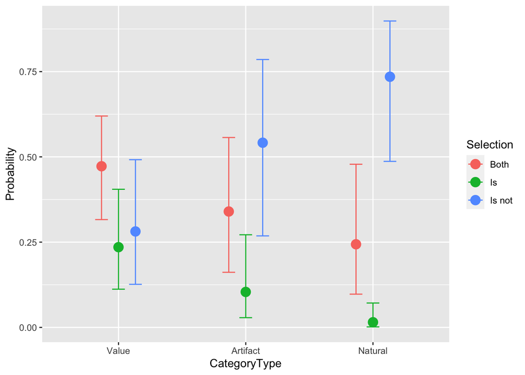

| CategoryType | Both | Is | Is not |
| --- | --- | --- | --- |
| Value | 0.47 [0.32 - 0.62] | 0.24 [0.11 - 0.4] | 0.28 [0.13 - 0.49] |
| Artifact | 0.34 [0.16 - 0.56] | 0.1 [0.03 - 0.27] | 0.54 [0.27 - 0.79] |
| Natural | 0.24 [0.1 - 0.48] | 0.02 [0 - 0.07] | 0.73 [0.49 - 0.9] |

## Added analysis 7-30-25

**Posterior Predictive Checks for all models**

**Model with default priors PPC**

```
## Using 10 posterior draws for ppc type 'dens_overlay' by default.
```

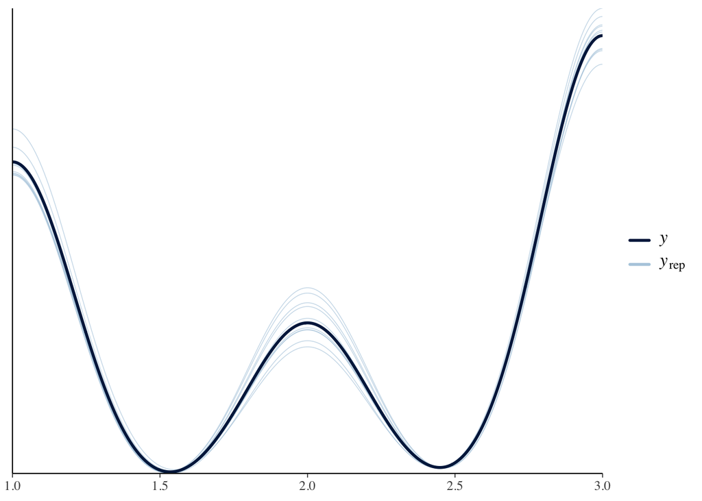

**Model with informed priors PPC**

```
## Using 10 posterior draws for ppc type 'dens_overlay' by default.
```

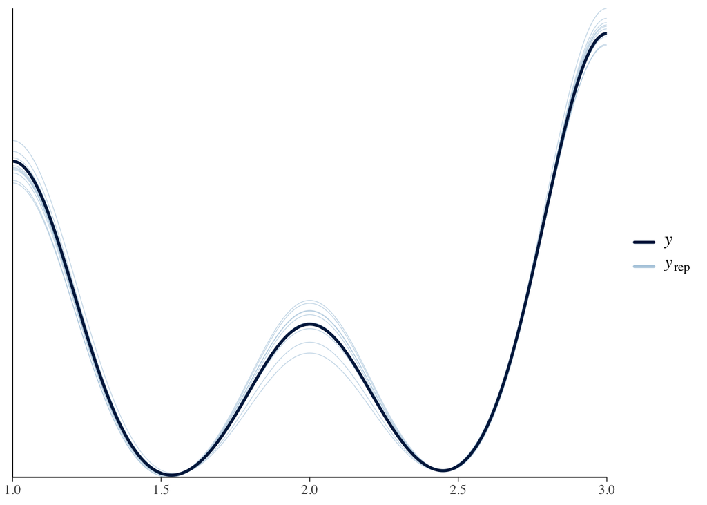

**Comparing model predictions for default and informed prior models**

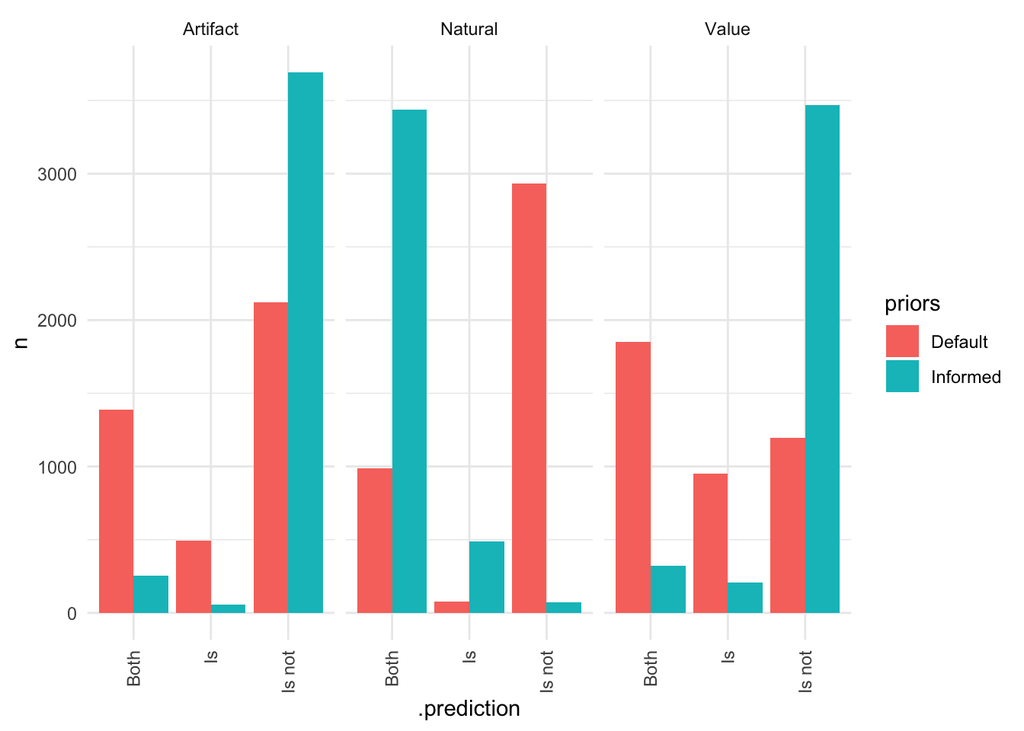

# The pairwise comparisons with default priors

## Both-both across categories **default**

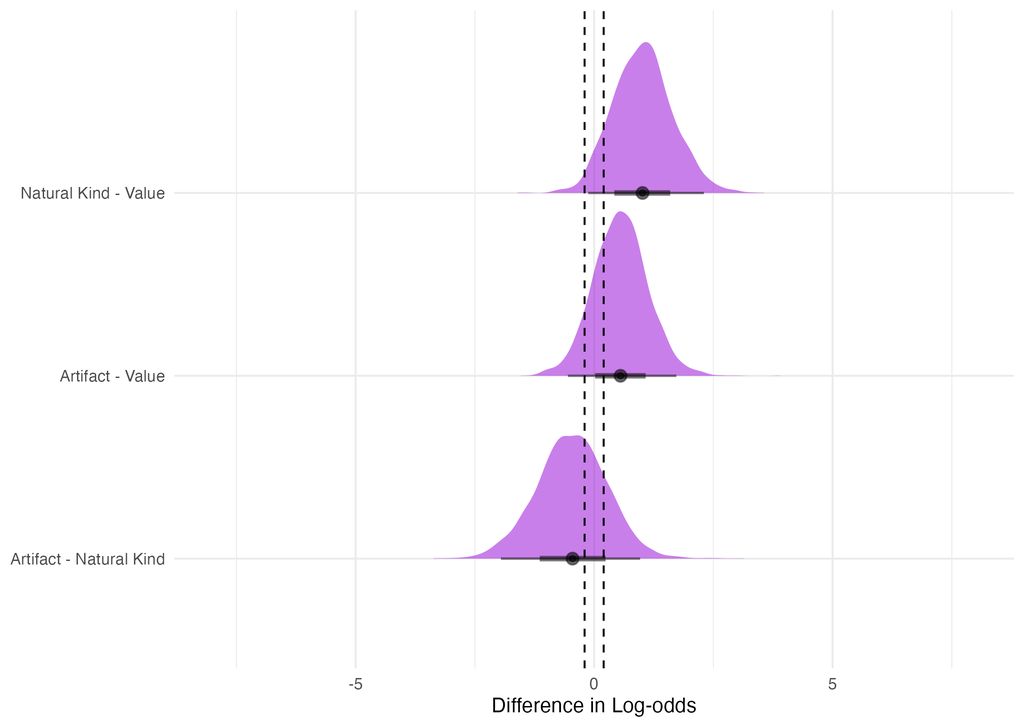

[output not shown]

# Is-is across categories **default**

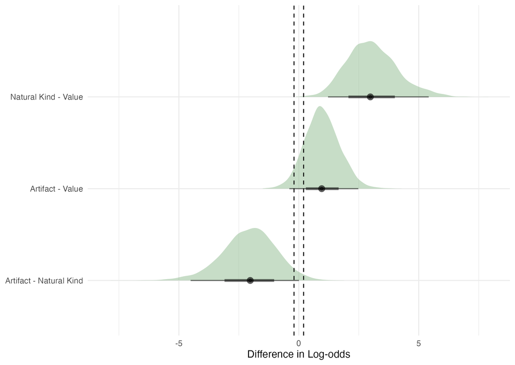

[output not shown]

# Is not - is not across categories **default**

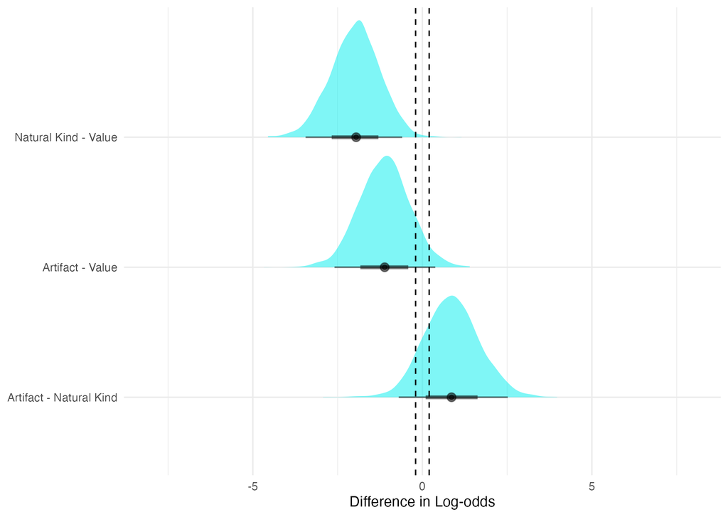

| Comparison | Effect | Compelling_difference |
| --- | --- | --- |
| Is not_Natural_Is not_Value | -1.98 [-3.36 - -0.53] | Yes |
| Is not_Artifact_Is not_Value | -1.12 [-2.6 - 0.37] | No |
| Is not_Artifact_Is not_Natural | 0.86 [-0.61 - 2.59] | No |

# Both, is, is not within natural kinds **default**

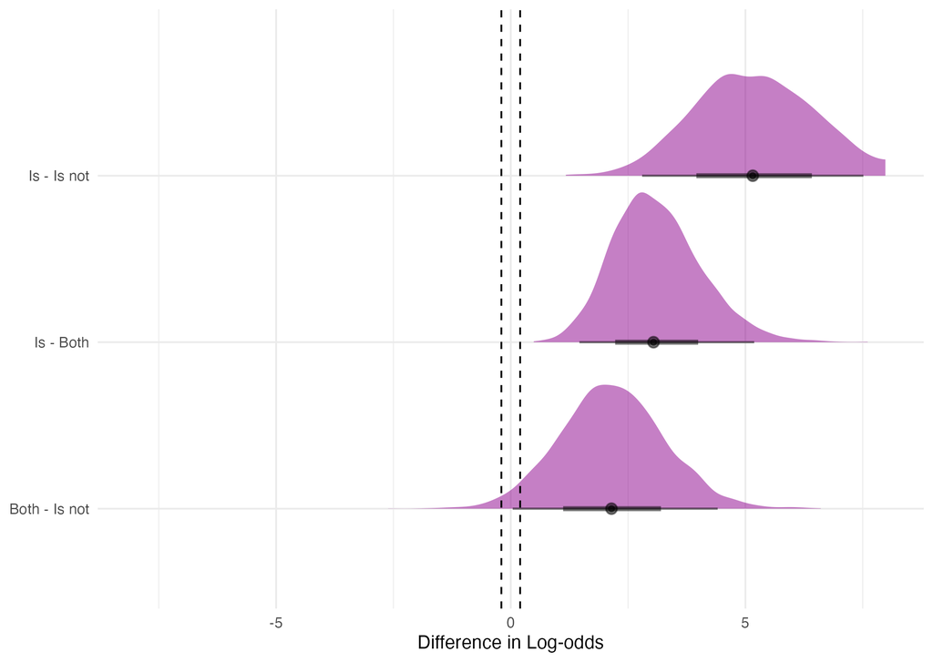

[output not shown]

# Both, is, is not within artifacts **default**

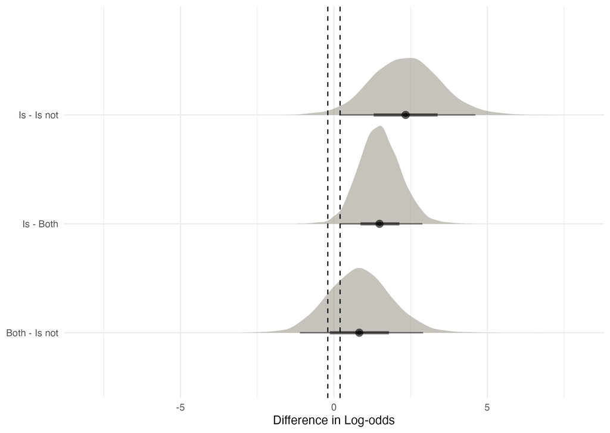

| Comparison | Effect | Compelling_difference |
| --- | --- | --- |
| Is_Artifact_Is not_Artifact | 2.34 [0.05 - 4.48] | Yes |
| Is_Artifact_Both_Artifact | 1.5 [0.26 - 2.9] | Yes |
| Both_Artifact_Is not_Artifact | 0.84 [-1.25 - 2.75] | No |

# Both, is, is not within value **default**

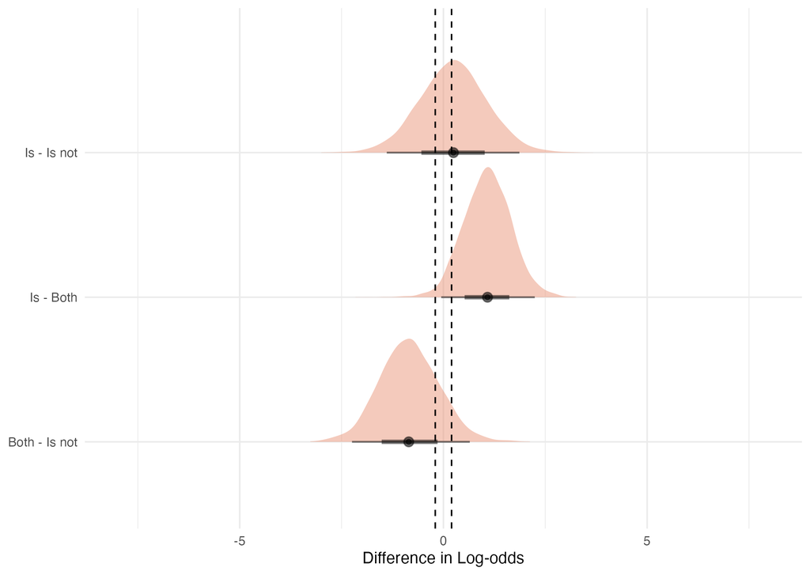

| Comparison | Effect | Compelling_difference |
| --- | --- | --- |
| Is_Value_Is not_Value | 0.24 [-1.38 - 1.87] | No |
| Is_Value_Both_Value | 1.08 [0 - 2.27] | No |
| Both_Value_Is not_Value | -0.84 [-2.19 - 0.7] | No |